# Analysis of a Policing Dataset from Dallas, Texas in 2016

Spoorthi Kalenahalli Basavalingaiah(sk22724)

2023-04-25

#### Introduction

The purpose of this project is to provide an analysis of a policing dataset from Dallas, Texas in 2016. The dataset used in this project is called `37-00049_UOF-P_2016_prepped`, which is available from the [Data Science for Good](https://www.kaggle.com/center-for-policing-equity/data-science-for-good) website.

#### Project Overview

In this project, we will explore and analyze the dataset to gain insights into policing practices in Dallas in 2016. We will focus on the following research questions:

- What are the demographic characteristics of individuals involved in police incidents?
- What types of police incidents are most common?
- Are there any patterns or trends in police incidents based on time, location, or other factors?
- What is the relationship between police incidents and race/ethnicity, gender, and age?

#### Data Description

The `37-00049_UOF-P_2016_prepped` dataset contains information on police incidents in Dallas, Texas in 2016. The data includes details on the individuals involved in the incidents, the type of incident, the date and time of the incident, and other relevant information.

```r
#libraries
library(ggmap)
library(shiny)
library(leaflet)
library(RColorBrewer)
library(tidyverse)
library(dplyr)
library(leaflet.extras)
library(lubridate)
library(gridExtra)
library(tidyr)
library(dplyr)
library(ggplot2)
library(ggridges)
library(viridis)
library(DT)
library(grid)
library(ggbeeswarm)
library(stringr)
library(RColorBrewer)
library(GGally)
```

```r
# read the CSV file into a data frame
df <- read.csv("/Users/spoor_ihd9451/Desktop/Data Visualisation/37-00049_UOF-P_2016_prepped.csv", na.strings = c(""))

df = df[-1,]

# Print the first few rows of the data
datatable(head(df), options = list(scrollX = TRUE, scrollY = "300px"))
```

|  | INCIDENT_DATE | INCIDENT_TIME | UOF_NUMBER | OFFICER_ID | OFFICER_GENDER | OFFICER_RACE | OFFICER_HIRE_DATE | OFFICER_YEARS_ON_FORCE | OFFICER_INJURY | OFFICER_INJURY_TYPE | OFFICER_HOSPITALIZATION | SUBJECT_ID | SUBJECT_RACE | SUBJECT_GENDER | SUBJECT_INJURY | SUBJECT_INJURY_TYPE | SUBJECT_WAS_ARRESTED | SUBJECT_DESCRIPTION | SUBJECT_OFFENSE | REPORTING_AREA | BEAT | SECTOR | DIVISION | LOCATION_DISTRICT | STREET_NUMBER | STREET_NAME | STREET_DIRECTION | STREET_TYPE | LOCATION_FULL_STREET_ADDRESS_OR_INTERSECTION | … |
| --- | --- | --- | --- | --- | --- | --- | --- | --- | --- | --- | --- | --- | --- | --- | --- | --- | --- | --- | --- | --- | --- | --- | --- | --- | --- | --- | --- | --- | --- | --- |
| 2 | 9/3/16 | 4:14:00 AM | 37702 | 10810 | Male | Black | 5/7/14 | 2 | No | No injuries noted or visible | No | 46424 | Black | Female | Yes | Non-Visible Injury/Pain | Yes | Mentally unstable | APOWW | 2062 | 134 | 130 | CENTRAL | D14 | 211 | Ervay | N | St. | 211 N ERVAY ST | … |
| 3 | 3/22/16 | 11:00:00 PM | 33413 | 7706 | Male | White | 1/8/99 | 17 | Yes | Sprain/Strain | Yes | 44324 | Hispanic | Male | No | No injuries noted or visible | Yes | Mentally unstable | APOWW | 1197 | 237 | 230 | NORTHEAST | D9 | 7647 | Ferguson | NULL | Rd. | 7647 FERGUSON RD | … |
| 4 | 5/22/16 | 1:29:00 PM | 34567 | 11014 | Male | Black | 5/20/15 | 1 | No | No injuries noted or visible | No | 45126 | Hispanic | Male | No | No injuries noted or visible | Yes | Unknown | APOWW | 4153 | 432 | 430 | SOUTHWEST | D6 | 716 | bimebella dr | NULL | Ln. | 716 BIMEBELLA LN | … |
| 5 | 1/10/16 | 8:55:00 PM | 31460 | 6692 | Male | Black | 7/29/91 | 24 | No | No injuries noted or visible | No | 43150 | Hispanic | Male | Yes | Laceration/Cut | Yes | FD-Unknown if Armed | Evading Arrest | 4523 | 641 | 640 | NORTH CENTRAL | D11 | 5600 | LBJ | NULL | Frwy. | 5600 L B J FWY | … |
| 6 | 11/8/16 | 2:30:00 AM | 37879, 37898 | 9844 | Male | White | 10/4/09 | 7 | No | No injuries noted or visible | No | 47307 | Black | Male | No | No injuries noted or visible | Yes | Unknown | Other Misdemeanor Arrest | 2167 | 346 | 340 | SOUTHEAST | D7 | 4600 | Malcolm X | S | Blvd. | 4600 S MALCOLM X BLVD | … |
| 7 | 9/11/16 | 7:20:00 PM | 36724 | 9855 | Male | White | 6/10/09 | 7 | No | No injuries noted or visible | No | 46549 | White | Female | No | No injuries noted or visible | Yes | Unknown | Assault/FV | 1134 | 235 | 230 | NORTHEAST | D9 | 1234 | Peavy | NULL | Rd. | 1234 PEAVY RD | … |

##### Time and Date conversion

```r
df$INCIDENT_DATE <- as.Date(df$INCIDENT_DATE, format = "%m/%d/%Y")
df$INCIDENT_DATE <- gsub("00","20",df$INCIDENT_DATE)
df$INCIDENT_DATE <- as.Date(df$INCIDENT_DATE, format = "%Y-%m-%d")
df$INCIDENT_TIME <- format(strptime(df$INCIDENT_TIME, "%I:%M:%S %p"), "%H:%M:%S")
df$INCIDENT_MONTH <- months(as.Date(df$INCIDENT_DATE))
df$INC_MONTH <-format(df$INCIDENT_DATE,"%m")
df$INCIDENT_HOUR <- as.numeric(substr(df$INCIDENT_TIME, 0, 2))
df$INCIDENT_DAY <- wday(df$INCIDENT_DATE, label=TRUE)
df$INC_HOUR <- substr(df$INCIDENT_TIME, 0, 2)
df$INC_DATE <- substr(df$INCIDENT_DATE, 9, 10)

## Create group of datas:

df_year <-  df %>%
  group_by(INCIDENT_DATE,INCIDENT_MONTH,INCIDENT_DAY) %>%
  summarize(count = n())
df_month <-  df %>%
  group_by(INC_MONTH) %>%
  summarize(count = n())

df_day <-  df %>%
  group_by(INCIDENT_DAY,INCIDENT_HOUR) %>%
  summarize(count = n())
df$INC_HOUR <- substr(df$INCIDENT_TIME, 0, 2)

df   %>% group_by(INC_HOUR) %>%
  summarize(avg =n()) -> df_hour_n
```

##### Incidents per month

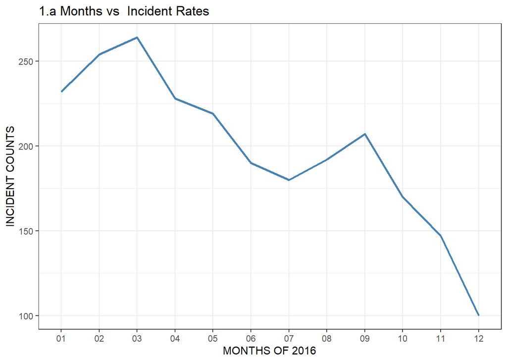

```r
r1 <- ggplot(df_month, aes(x=INC_MONTH, y =count, group=1)) + geom_line()  + geom_line( linewidth = 1,colour ="steelblue") + labs(x="MONTHS OF 2016", y= "INCIDENT COUNTS", title="1.a Months vs  Incident Rates")  + theme_bw()
r1
```

The incident rate showed a gradual decline over the course of the year, with the highest rate occurring in March and the lowest rate in December.

##### Incidents vs time

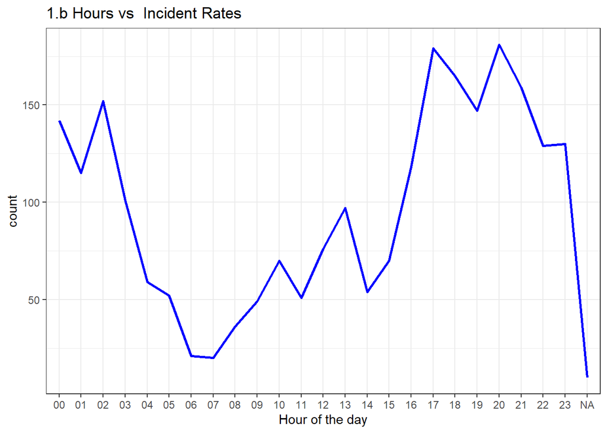

```r
r2 <- ggplot(df_hour_n, aes(x = INC_HOUR, y = avg, group = "count")) + geom_line( size = 1, colour = "blue") + labs(x="HOURS IN A DAY", y= "INCIDENT COUNTS", title="1.b Hours vs  Incident Rates")+ theme_bw() +
theme(axis.text.x=element_text(angle=-90, vjust=0.5)) +

  labs(x = "Hour of the day", y = "count") + theme_bw()
r2
```

In 2016, the number of reported incidents decreased overall, with peaks observed during the hours of 17:00-20:00 and 02:00, and the lowest number of incidents reported between 04:00-10:00 and at 07:00.

##### Distribution of crimes across months and days

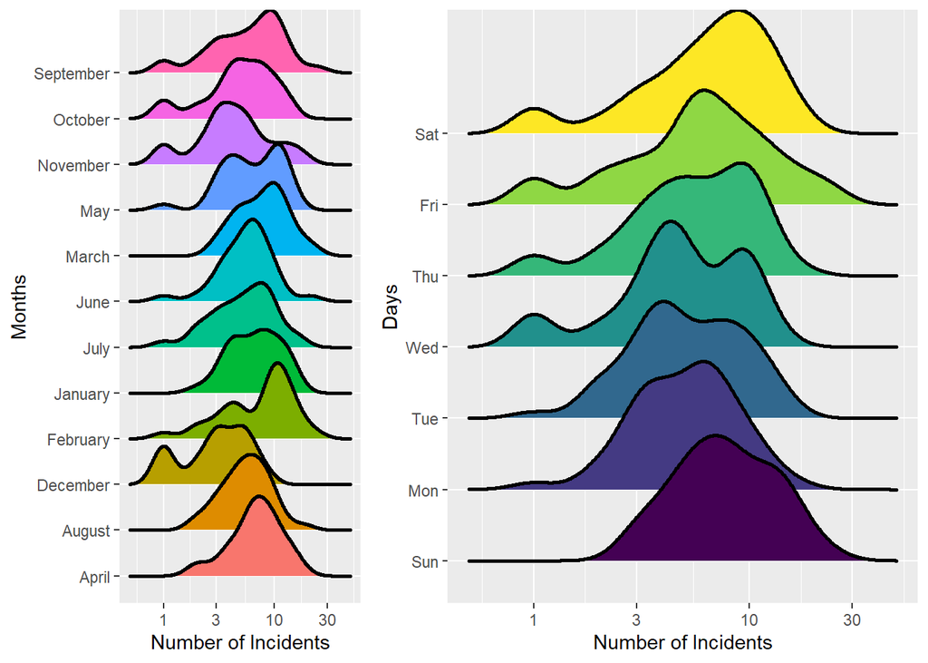

The analysis shows that the incident counts follow a normal distribution in the months of March, June, July, January, August, and April, while two peaks were observed in December, February, May, and October. A left-skewed distribution was observed in September. On weekdays, the incident rate is normally distributed on Sundays, while Wednesdays exhibit multi-modality with smaller nodes observed on Wednesdays, Thursdays, Fridays, and Saturdays. The average range of incidents for both days and months is between 3 to 20.

##### Subject race vs Incident Date

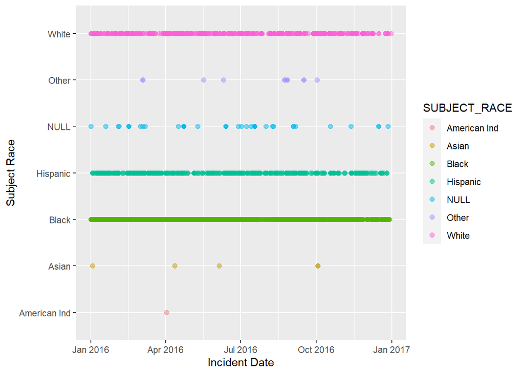

```r
# Create a scatter plot with incident dates on the x-axis, subject races on the y-axis, and color-coded points
ggplot(df, aes(x=INCIDENT_DATE, y=SUBJECT_RACE, color=SUBJECT_RACE)) +
  geom_point(size=2, alpha=0.5) +
  xlab("Incident Date") + ylab("Subject Race")
```

It is important to note that correlation does not imply causation. Simply observing a relationship between subject race and incident rates does not prove that race is the cause of the incidents. There may be other factors, such as socioeconomic status or location, that are influencing the relationship.

##### Central tendency of incident rates involving different subject races

```r
df_srace <-  df %>%
  group_by(INC_MONTH,INCIDENT_MONTH,SUBJECT_RACE) %>%
  summarize(count = n())
df_orace <-  df %>%
  group_by(INC_MONTH,INCIDENT_MONTH,OFFICER_RACE) %>%
  summarize(count = n())
```

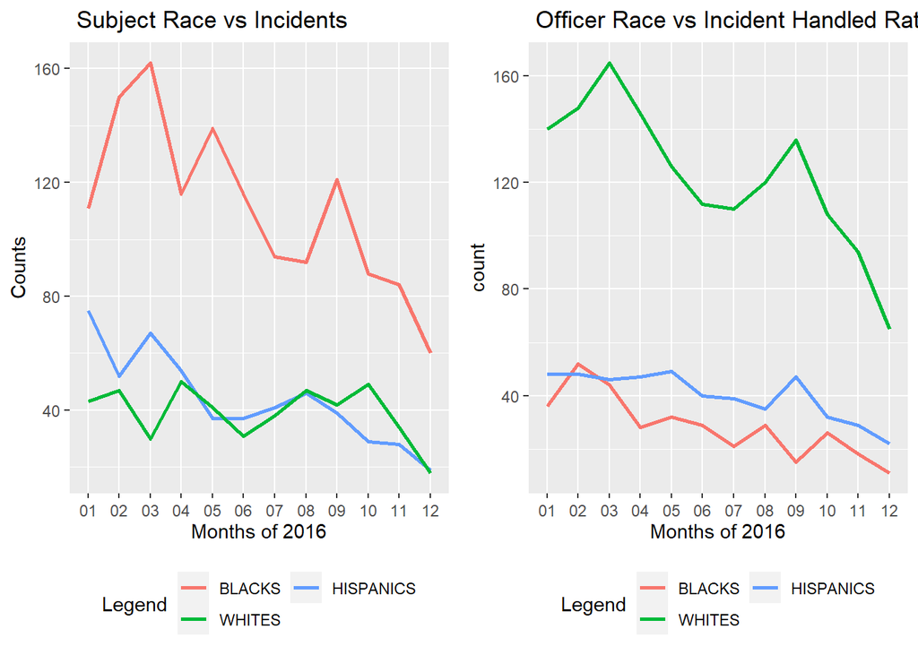

```r
c1 <- ggplot() +
geom_line(data=subset(df_srace, SUBJECT_RACE=="Black" ) ,aes(y=count,x= INC_MONTH,colour="green",group=1),size=1 ) +
geom_line(data=subset(df_srace, SUBJECT_RACE=="Hispanic" ) ,aes(y=count,x= INC_MONTH,colour="red",group=1),size=1 ) +
  geom_line(data=subset(df_srace, SUBJECT_RACE=="White" ) ,aes(y=count,x= INC_MONTH,colour="orange",group=1),size=1 ) +
  scale_color_discrete(name = "Y series", labels = c("BLACKS", "WHITES","HISPANICS")) + labs(x="Months of 2016", y= "Counts", title=" Subject Race vs Incidents")  +
  scale_color_discrete(name = "Legend", labels = c("BLACKS", "WHITES","HISPANICS"))  + theme(axis.text.x=element_text( vjust=0.5),legend.position="bottom") +guides(colour=guide_legend(nrow=2))
c2 <- ggplot() +
  geom_line(data=subset(df_orace, OFFICER_RACE=="Black" ) ,aes(y=count,x= INC_MONTH,colour="green",group=1),size=1 ) +
  geom_line(data=subset(df_orace, OFFICER_RACE=="Hispanic" ) ,aes(y=count,x= INC_MONTH,colour="red",group=1),size=1 ) +
  geom_line(data=subset(df_orace, OFFICER_RACE=="White" ) ,aes(y=count,x= INC_MONTH,colour="orange",group=1),size=1 ) +
  scale_color_discrete(name = "Y series", labels = c("BLACKS", "WHITES","HISPANICS")) + labs(x="Months of 2016", title=" Officer Race vs Incident Handled Rates")  +
  scale_color_discrete(name = "Legend", labels = c("BLACKS", "WHITES","HISPANICS"))  + theme(axis.text.x=element_text( vjust=0.5),legend.position="bottom")+guides(colour=guide_legend(nrow=2))
layout <- matrix(c(1,1,1,1,2,2,2,2),3,8,byrow=TRUE)

multiplot(c1, c2, layout=layout)
```

##### Gender and Race of Officers

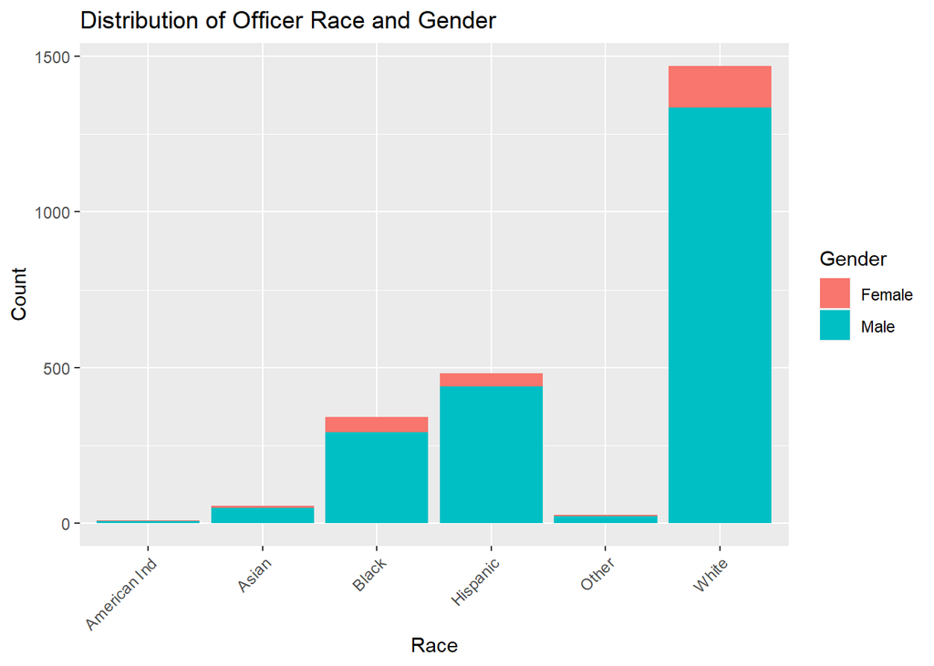

```r
# calculate the number of officers by race and gender
race_gender_counts <- aggregate(df$UOF_NUMBER, by=list(df$OFFICER_RACE, df$OFFICER_GENDER), FUN=length)
colnames(race_gender_counts) <- c("Race", "Gender", "Count")

# create a stacked bar chart of officer race and gender
ggplot(race_gender_counts, aes(x=Race, y=Count, fill=Gender)) +
  geom_bar(stat="identity") +
  labs(title="Distribution of Officer Race and Gender", x="Race", y="Count") +
  theme(axis.text.x = element_text(angle = 45, hjust = 1))
```

##### Gender and Race of Subjects

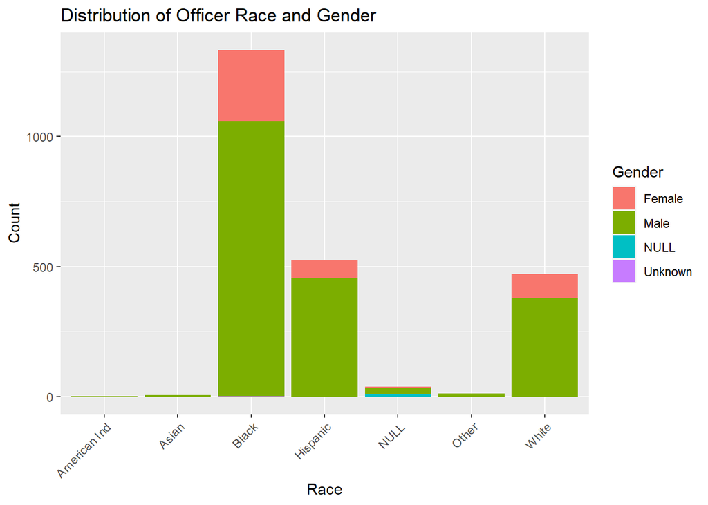

```r
# calculate the number of officers by race and gender
race_gender_counts <- aggregate(df$UOF_NUMBER, by=list(df$SUBJECT_RACE
, df$SUBJECT_GENDER), FUN=length)
colnames(race_gender_counts) <- c("Race", "Gender", "Count")

# create a stacked bar chart of officer race and gender
ggplot(race_gender_counts, aes(x=Race, y=Count, fill=Gender)) +
  geom_bar(stat="identity") +
  labs(title="Distribution of Officer Race and Gender", x="Race", y="Count") +
  theme(axis.text.x = element_text(angle = 45, hjust = 1))
```

##### Division vs Incidents

```r
# Filter out rows with missing or invalid values in relevant columns
df <- df %>% filter(!is.na(INC_MONTH), !is.na(DIVISION))

# Create division-wise incident count data frame
df_div <- df %>% group_by(INC_MONTH, DIVISION) %>% summarize(count = n())
```

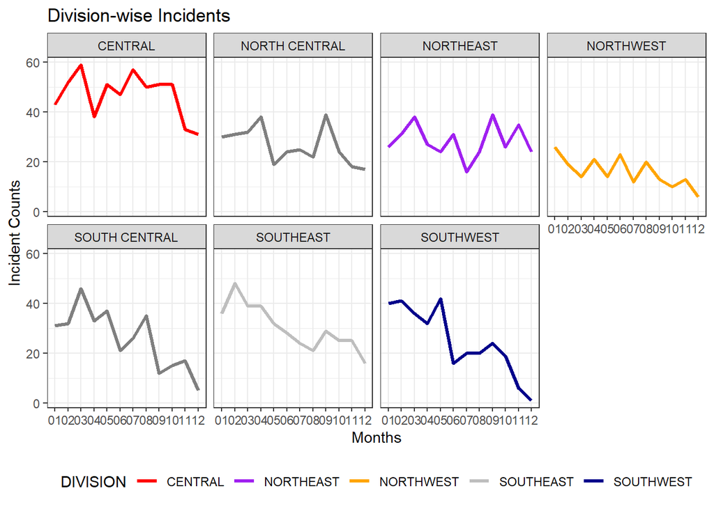

```r
# Define color palette for different divisions
color_pal <- c("CENTRAL" = "red",
               "EAST" = "blue",
               "NORTH" = "green",
               "NORTHEAST" = "purple",
               "NORTHWEST" = "orange",
               "SOUTH" = "pink",
               "SOUTHEAST" = "gray",
               "SOUTHWEST" = "darkblue")

# Create line plot for each division
p <- ggplot(df_div, aes(x = INC_MONTH, y = count, group = DIVISION, color = DIVISION)) +
  geom_line(size = 1.2) +
  scale_color_manual(values = color_pal) +
  labs(x = "Months", y = "Incident Counts", title = "Division-wise Incidents") +
  theme_bw() +
  theme(legend.position = "bottom") +
  facet_wrap(~DIVISION, ncol = 4)

# Show the plot
p
```

##### Localization of Crime incidents

```r
# Convert LOCATION_LONGITUDE and LOCATION_LATITUDE columns to numeric
df$LOCATION_LONGITUDE <- as.numeric(df$LOCATION_LONGITUDE)
df$LOCATION_LATITUDE <- as.numeric(df$LOCATION_LATITUDE)

# Create a map using the converted columns
library(leaflet)
my_map <- leaflet() %>%
  addTiles() %>%
  addMarkers(data = df, lng = ~LOCATION_LONGITUDE, lat = ~LOCATION_LATITUDE)
# Display the map
my_map
```

[interactive chart not shown]

##### Crime Trends by location

```r
# Filter out rows with missing or invalid lat/lon values
df <- df %>% filter(!is.na(LOCATION_LATITUDE), !is.na(LOCATION_LONGITUDE))

# Extract first word of INCIDENT_REASON column
df$reason <- sub("\\s.*", "", df$INCIDENT_REASON)

# Extract unique reasons from REASON_FOR_FORCE column
unique_reasons <- unique(sub("\\s.*", "", df$reason))

# Define color palette for different reasons
color_pal <- setNames(rainbow(length(unique_reasons)), unique_reasons)


# Create map plot
m <- leaflet(df) %>%
  addTiles() %>%
  addCircleMarkers(lng = ~LOCATION_LONGITUDE, lat = ~LOCATION_LATITUDE,
                   color = ~color_pal[sub("\\s.*", "", reason)],
                   radius = 2,
                   stroke = FALSE,
                   fillOpacity = 0.8) %>%
  addLegend(position = "bottomright",
            title = "Incident Reason",
            colors = color_pal,
            labels = names(color_pal))

# Show the map
m
```

[output not shown]

[interactive chart not shown]

```r
df_subdes <-  df %>%
  group_by(INCIDENT_DATE,INCIDENT_MONTH,INCIDENT_DAY,SUBJECT_DESCRIPTION) %>%
  summarize(count = n())
```

[output not shown]

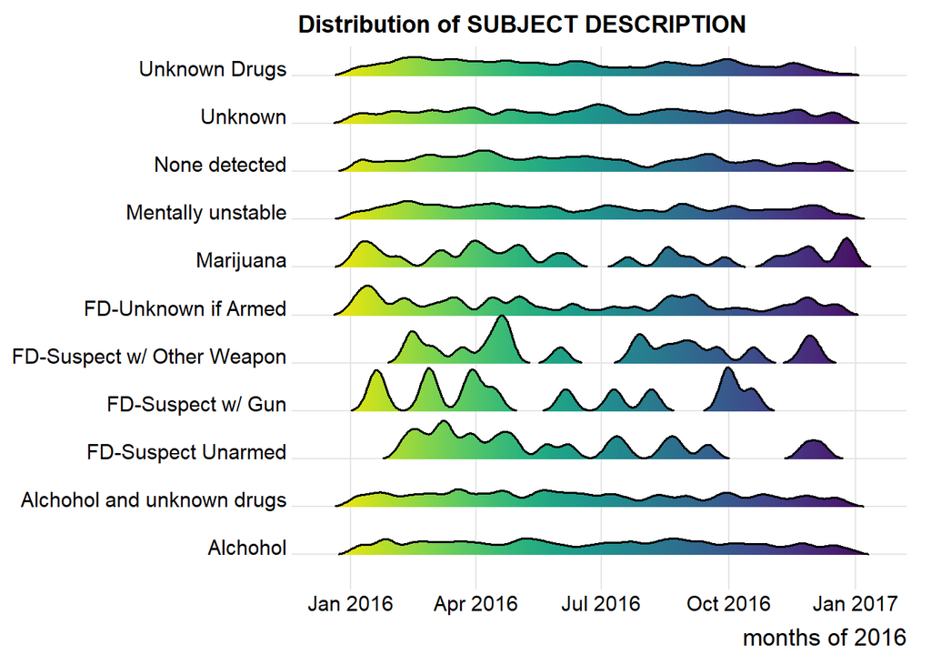

```r
ggplot(subset(df_subdes,SUBJECT_DESCRIPTION != "FD-Motor Vehicle" & SUBJECT_DESCRIPTION != "NULL" & SUBJECT_DESCRIPTION != "FD-Animal" & SUBJECT_DESCRIPTION != "Animal"), aes(x = INCIDENT_DATE, y = SUBJECT_DESCRIPTION, fill = ..x..)) +

  geom_density_ridges_gradient(size=0.7,scale = 1, rel_min_height = 0.01, gradient_lwd = 1., bandwidth = 6,alpha = 1.5) +
   scale_fill_viridis(name = "Tail probability", direction = -1) +

  ggtitle("Distribution of SUBJECT DESCRIPTION") +

  labs(x = "months of 2016", y = "", fill = "Humidity") +

  theme_ridges(font_size = 13, grid = TRUE) +

  theme(legend.position = "none") +

  theme(axis.title.y = element_blank())
```

##### Conclusion

Key insights from the data analysis reveal a decreasing trend in incident rates over time, peak incident hours between 17:00 and 20:00, and a contrast in incident rates between Black and White subjects/officers. Additionally, Central Division had the highest number of incidents, and suspects with guns and weapons had recurring peaks in incident rates. Time series analysis provided insights into trends, seasonality, and the racial backgrounds of officers and subjects. These insights can inform effective prevention and intervention strategies.